# Corpora Exploratory Analysis

Sergey Sambor

October 29, 2017

## Executive Summary

In this document I report the structure and summaries of SwiftKey dataset. I explain and describe the way the dataset must be cleaned. Using *tm* and other packages I show features, insights and the most frequent ngrams of the provided dataset.

## Data

```
##                                 file file.size.MB num.lines.M num.words.M
## 1   data/final/en_US/en_US.blogs.txt          210        0.90       37.55
## 2    data/final/en_US/en_US.news.txt          206        1.01       34.76
## 3 data/final/en_US/en_US.twitter.txt          167        2.36       30.09
```

## Data Analysis

For analysis I use several tools/libraries  
*dplyr* - for data manipulation  
*ggplot2* - plotting and visualising  
*tm* - text mining library  
*RWeka* - for splitting text int n-grams

Because of the reason only the one third of the text is news and therefore is written without errors (we may expect), the other two thirds are containing errors of any kind one can imagine. We need to deal with that errors, but, firstly to determine those errors.  
The full dataset is too ‘heavy’ for an exploratory analysis: tm package cannot build TermDocumentMatrix in the memory straightaway, but splitting the dataset into chunks and incrementally construct all TermDocumentMatrices takes 3 hours (11240.328 seconds correctly). So I take a small sample out of the dataset.  
Algorithm for sampling will be as follows: reading all three files chunk by chunk (1000 lines each) and randomly take 20 lines out of every chunk. That is representative 2% of all data.

### Preprocessing and tokenizing data points

1 remove all punctuations marks that follow each other: Twitter feeds contain smiles and, for example, many exclamation marks in a row  
2 leave only three punctuation marks, that are part of the language: “can’t”, “i.e.”, “left-handed”  
3 don’t make all text in lowercase, because prediction for “Las” should be “Vegas”, but not “vegas”  
4 include stopwords - “to be or not to be” consists fully of stopwords etc.  
5 set the minimal word length to 1 - see above  
6 no stemming is used  
7 don’t remove numbers - “Porsche 911”, “Elections 2012”  
8 dataset contains only one sentence in each line, because words from the opposite sides of a dot don’t make a bigram (trigram, whatsoever)  
Actually, the last point decreased by 7% in sample dataset the total number of bigrams only. Now, let’s have a look at the most frequent bigrams of a sample data.

```r
setwd("..")
corp <- VCorpus(DirSource("data/sample/"))
nGramTok <- function(x) NGramTokenizer(x, Weka_control(min = 2, max = 2, delimeters = ' \r\n\t,;:"()?!'))
tdm <- TermDocumentMatrix(corp, list(wordLengths = c(1,Inf),
                                    tolower = FALSE,
                                    stopwords = FALSE,
                                    tokenize = nGramTok))
(head(findFreqTerms(tdm, 800), 40))
```

```
##  [1] "about the" "a little"  "all the"   "a lot"     "and a"
##  [6] "and I"     "and the"   "as a"      "at the"    "be a"
## [11] "but I"     "by the"    "can t"     "didn t"    "don t"
## [16] "for a"     "for the"   "from the"  "going to"  "has been"
## [21] "have a"    "have been" "have to"   "I am"      "I can"
## [26] "I don"     "if you"    "I had"     "I have"    "I love"
## [31] "I m"       "in a"      "in the"    "is a"      "is the"
## [36] "I think"   "it is"     "it s"      "It s"      "it was"
```

These “can t”, “I m”, “I don” and other iterative examinations bring us additional points - insert “’” where needed  
- replace shortenings “c” and “u” with “see” and “you” respectively  
- remove “bad” words; a good sample of the list - https://github.com/LDNOOBW/List-of-Dirty-Naughty-Obscene-and-Otherwise-Bad-Words  
- make all “i”s (as pronouns) big

```r
setwd("..")
corp <- VCorpus(DirSource("data/chunks/"))

Terms1 <- customTDM1(corp)
Terms2 <- customTDMn(corp, 2)
(head(findFreqTerms(Terms2, 1400), 40))
```

```
##  [1] "about the" "a few"     "a little"  "all the"   "a lot"
##  [6] "and a"     "and I"     "and the"   "as a"      "at the"
## [11] "be a"      "by the"    "for a"     "for the"   "from the"
## [16] "going to"  "has been"  "have a"    "have been" "have to"
## [21] "I am"      "I don't"   "I had"     "I have"    "in a"
## [26] "in the"    "into the"  "is a"      "is the"    "I think"
## [31] "it is"     "it was"    "I was"     "more than" "need to"
## [36] "of a"      "of my"     "of the"    "on a"      "one of"
```

```r
Terms3 <- customTDMn(corp, 3)
Terms4 <- customTDMn(corp, 4)
```

As it can be seen, bigrams slightly changed. Now it’s time to explore core things in frequencies of the most popular ngrams.

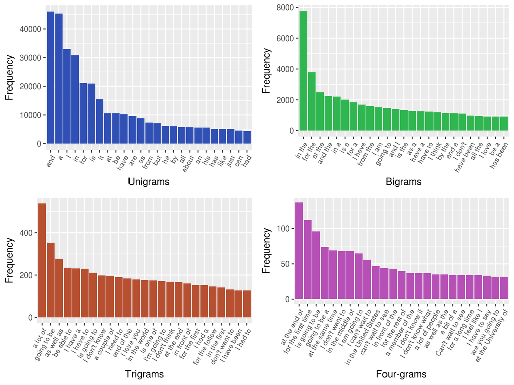

## Next Steps

In the next steps I’ll build a model to predict a word by its predecessors. I’ll find a way to combine frequencies from different ngrams - for now I have no clue how to deal with a case, when, for example, bigram with frequency 300 suggests word “AAA”, but four-gram with frequency 80 suggests word “BBB”. The resulting algorithm will be deployed as a Shiny App.